# Tn-seq fitness correction in Streptococcus pneumoniae genome

# Linear regression

A technique that can be used to correct fitness measures involves dividing the genome into segments and employing the mean values within those segments as Y and the genomic location of the midpoint of each segment as X in a **linear regression model**.

## Linear coordinates

After dividing the genome into windows of default size 100000, the new dataframe containes:

- `middle_coordinate`: the genome position of the middle of the window;
- `radians`: the `middle_coordinate` converted into radians;
- `avg_fitness`: the average values of fitness within windows.

```r
windowProperties <- function(GrangeObj, windowSize = 1e+05) {
    # Get the start and end coordinates of the genomic regions
    start_coords <- start(GrangeObj)
    end_coords <- end(GrangeObj)

    genome_length <- max(end_coords)  #calculate genome length as highest values among the one retrieved with end function
    num_windows <- ceiling(genome_length/windowSize)  #calculate the number of windows, rounding up to the next integer

    # Initialize numeric vectors to store the window statistics
    window_coordinates <- numeric(num_windows)
    window_radians <- numeric(num_windows)
    window_avg_fitness <- numeric(num_windows)

    # Assigning to offset the minimum start coordinate of the genomic regions
    offset <- min(start_coords)

    # Iterate over the windows
    for (i in 1:num_windows) {
        # Define window start and end coordinates
        window_start <- (i - 1) * windowSize + offset
        window_end <- i * windowSize + offset - 1

        # Find the indices of genomic regions within the window
        indices <- which(start_coords <= window_end & end_coords >= window_start)

        # Check if any regions overlap with the window
        if (length(indices) > 0) {
            # Compute the middle coordinate and average fitness for the window
            window_coordinates[i] <- round((window_end + window_start)/2)
            window_radians[i] <- window_coordinates[i] * 2 * pi/genome_length
            window_avg_fitness[i] <- mean(GrangeObj$avg_fitness[indices])
        }
    }

    # Create a dataframe with the window statistics
    df <- data.frame(middle_coordinate = window_coordinates, radians = window_radians,
        avg_fitness = window_avg_fitness)

    return(df)
}

windows_properties <- windowProperties(fitness)
windows_properties
```

```
   middle_coordinate   radians avg_fitness
1              51716 0.1503782   1.0202464
2             151716 0.4411553   1.0247342
3             251716 0.7319323   1.0187164
4             351716 1.0227093   1.0005333
5             451716 1.3134863   0.9972576
6             551716 1.6042633   1.0085714
7             651716 1.8950403   1.0015294
8             751716 2.1858173   0.9857317
9             851716 2.4765943   0.9847536
10            951716 2.7673714   0.9837976
11           1051716 3.0581484   0.9913194
12           1151716 3.3489254   0.9845278
13           1251716 3.6397024   0.9758101
14           1351716 3.9304794   0.9995541
15           1451716 4.2212564   0.9830923
16           1551716 4.5120334   0.9984533
17           1651716 4.8028105   1.0143382
18           1751716 5.0935875   1.0038817
19           1851716 5.3843645   1.0094189
20           1951716 5.6751415   1.0278514
21           2051716 5.9659185   1.0295443
22           2151716 6.2566955   1.0332000
```

Let’s consider just one half of the genome divided in windows to calculate the window properties and to train the model.

```r
midpoint <- genomeLength/2
midpoint
```

```
[1] 1080413
```

```r
# Since the midpoint is 1080413, I can split windows_properties obj in half to
# get the first half of the genome
first_half <- windows_properties[1:11, ]
# training linear regression model with the first half of the genome
lm_lin_coord <- lm(formula = avg_fitness ~ middle_coordinate, data = first_half)
summary(lm_lin_coord)
```

```
Call:
lm(formula = avg_fitness ~ middle_coordinate, data = first_half)

Residuals:
      Min        1Q    Median        3Q       Max
-0.008950 -0.006420 -0.001117  0.006141  0.009557

Coefficients:
                    Estimate Std. Error t value Pr(>|t|)
(Intercept)        1.023e+00  4.417e-03 231.688  < 2e-16 ***
middle_coordinate -3.960e-08  6.946e-09  -5.701 0.000294 ***
---
Signif. codes:  0 '***' 0.001 '**' 0.01 '*' 0.05 '.' 0.1 ' ' 1

Residual standard error: 0.007285 on 9 degrees of freedom
Multiple R-squared:  0.7831,    Adjusted R-squared:  0.759
F-statistic:  32.5 on 1 and 9 DF,  p-value: 0.0002939
```

The p-values are significant (alpha < 0.01) indicating that there is strong evidence to reject the null hypothesis that the true coefficient is zero. Therefore, there is a significant relationship between the `middle_coordinate` and `avg_fitness` variables. The R squared is also quite high, indicating that approximately 78% of the variance in fitness can be explained by the linear regression model.

Let’s also calculate the Mean Square Error for the linear regression model.

```r
predicted_first_half <- predict(lm_lin_coord, first_half)
sqr_residuals <- (first_half$avg_fitness - predicted_first_half)^2
mse <- mean(sqr_residuals)
mse
```

```
[1] 4.342459e-05
```

The calculated mean squared error (MSE) of 4.342459e-05 indicates that model’s predictions are quite close to the actual values, with very little error.

Let’s consider the second half of the genome divided in windows and predict the fitness values.

```r
second_half <- windows_properties[12:22, ]

reversed_coordinates <- genomeLength - second_half$middle_coordinate


predicted_second_half <- predict(lm_lin_coord, newdata = data.frame(middle_coordinate = reversed_coordinates,
    avg_fitness = second_half$avg_fitness))

mse <- mean((predicted_second_half - second_half$avg_fitness)^2)

mse
```

```
[1] 7.858141e-05
```

The MSE is still very low, demonstrating that the linear model is suitable to train both train and test data ( second half of the genome divided in windows). So, the linear model can be used to correct the fitness values, which look higher at the extremities of the graph in Section 2.1.

```r
# Correcting fitness values for first and second half of genome

# Data gets shifted by one since it's assumed that the fitness values are
# around 1
first_half$corrected_fitness <- first_half$avg_fitness - predicted_first_half + 1
first_half$corrected_fitness
```

```
 [1] 0.9988835 1.0073313 1.0052736 0.9910505 0.9917347 1.0070086 1.0039266
 [8] 0.9920889 0.9950708 0.9980748 1.0095566
```

```r
second_half$corrected_fitness <- second_half$avg_fitness - predicted_second_half +
    1
second_half$corrected_fitness
```

```
 [1] 1.0010778 0.9884001 1.0081840 0.9877623 0.9991633 1.0110882 0.9966717
 [8] 0.9982489 1.0127213 1.0104542 1.0101499
```

```r
# Create one dataframe containing all the genome windows
all_windows <- rbind(first_half, second_half)
all_windows
```

```
   middle_coordinate   radians avg_fitness corrected_fitness
1              51716 0.1503782   1.0202464         0.9988835
2             151716 0.4411553   1.0247342         1.0073313
3             251716 0.7319323   1.0187164         1.0052736
4             351716 1.0227093   1.0005333         0.9910505
5             451716 1.3134863   0.9972576         0.9917347
6             551716 1.6042633   1.0085714         1.0070086
7             651716 1.8950403   1.0015294         1.0039266
8             751716 2.1858173   0.9857317         0.9920889
9             851716 2.4765943   0.9847536         0.9950708
10            951716 2.7673714   0.9837976         0.9980748
11           1051716 3.0581484   0.9913194         1.0095566
12           1151716 3.3489254   0.9845278         1.0010778
13           1251716 3.6397024   0.9758101         0.9884001
14           1351716 3.9304794   0.9995541         1.0081840
15           1451716 4.2212564   0.9830923         0.9877623
16           1551716 4.5120334   0.9984533         0.9991633
17           1651716 4.8028105   1.0143382         1.0110882
18           1751716 5.0935875   1.0038817         0.9966717
19           1851716 5.3843645   1.0094189         0.9982489
20           1951716 5.6751415   1.0278514         1.0127213
21           2051716 5.9659185   1.0295443         1.0104542
22           2151716 6.2566955   1.0332000         1.0101499
```

Let’s visualize two scatterplots plotting the fitness values against the `middle_coordinate` before and after fitness correction.

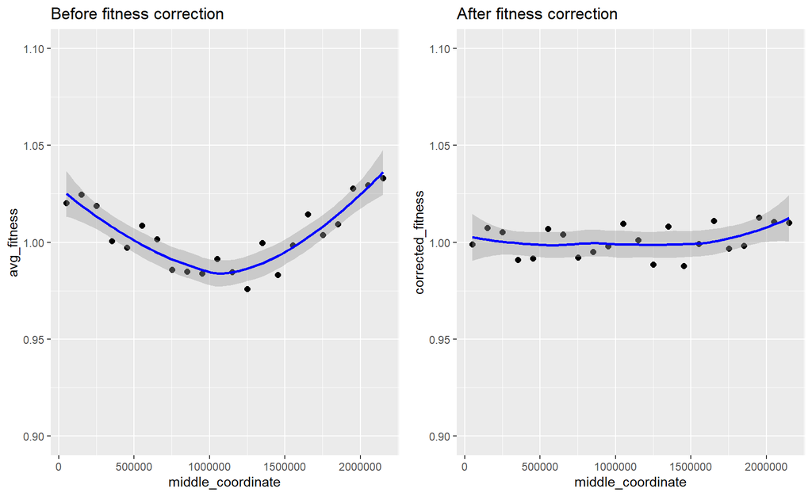

```r
# Create the scatterplot for avg_fitness
plot_avg_fitness <- ggplot(all_windows, aes(x = middle_coordinate, y = avg_fitness)) +
    geom_point(size = 2) + geom_smooth(method = "density") + geom_smooth(color = "blue") +
    ylim(0.9, 1.1) + labs(title = "Before fitness correction", x = "middle_coordinate",
    y = "avg_fitness")
# Create the scatterplot for corrected_fitness
plot_corrected_fitness <- ggplot(all_windows, aes(x = middle_coordinate, y = corrected_fitness)) +
    geom_point(size = 2) + geom_smooth(method = "density") + geom_smooth(color = "blue") +
    ylim(0.9, 1.1) + labs(title = "After fitness correction", x = "middle_coordinate",
    y = "corrected_fitness")

# Arrange the plots side by side
combined_plots <- grid.arrange(plot_avg_fitness, plot_corrected_fitness, ncol = 2)
```

After fitness correction, the banana shape is strongly reduced. The linear model can be now used to correct fitness on the original `fitness` object, and consequently correcting the gene category assigned, taking into account that the second half of the genome needs to be reversed.

```r
# first half of fitness grange obj not divided in windows
fitness_first_half <- subsetByOverlaps(fitness, GRanges("chr", IRanges(0, genomeLength/2)))
fitness_first_half_df <- data.frame(middle_coordinate = fitness_first_half$middleCoord,
    avg_fitness = fitness_first_half$avg_fitness, gene_category = fitness_first_half$geneCategory)
# predict corrected fitness for the first half of genome
predicted_fitness_first_half_df <- predict(lm_lin_coord, fitness_first_half_df)
fitness_first_half_df$corrected_fitness <- fitness_first_half_df$avg_fitness - predicted_fitness_first_half_df +
    1

# second half of fitness grange obj not divided in windows
fitness_second_half <- subsetByOverlaps(fitness, GRanges("chr", IRanges(genomeLength/2,
    genomeLength)))
fitness_second_half_df <- data.frame(middle_coordinate = fitness_second_half$middleCoord,
    avg_fitness = fitness_second_half$avg_fitness, gene_category = fitness_second_half$geneCategory)

# predict corrected fitness for the second half of genome
reversed_coordinates_second_half_df <- genomeLength - fitness_second_half_df$middle_coordinate
predicted_fitness_second_half_df <- predict(lm_lin_coord, newdata = data.frame(middle_coordinate = reversed_coordinates_second_half_df,
    avg_fitness = fitness_second_half_df$avg_fitness))
fitness_second_half_df$corrected_fitness <- fitness_second_half_df$avg_fitness -
    predicted_fitness_second_half_df + 1


# bind the two dataframes into one
fitness_df_all <- rbind(fitness_first_half_df, fitness_second_half_df)

# take out duplicates
fitness_df_all <- fitness_df_all[!duplicated(fitness_df_all$middle_coordinate), ]

# create another column with the corrected gene category
fitness_df_all$corrected_gene_category <- cut(fitness_df_all$corrected_fitness, breaks = c(0,
    0.96, 1.04, Inf), labels = c("Disadvantageous", "Neutral", "Advantageous"))
head(fitness_df_all, 5)
```

```
  middle_coordinate avg_fitness gene_category corrected_fitness
1              2285       1.082  Advantageous         1.0586797
2              3015       1.013       Neutral         0.9897086
3              3754       0.963       Neutral         0.9397378
4              4666       1.063  Advantageous         1.0397740
5              6706       1.051  Advantageous         1.0278547
  corrected_gene_category
1            Advantageous
2                 Neutral
3         Disadvantageous
4                 Neutral
5                 Neutral
```

Let’s plot the fitness values before and after correction against the `middle_coordinate`.

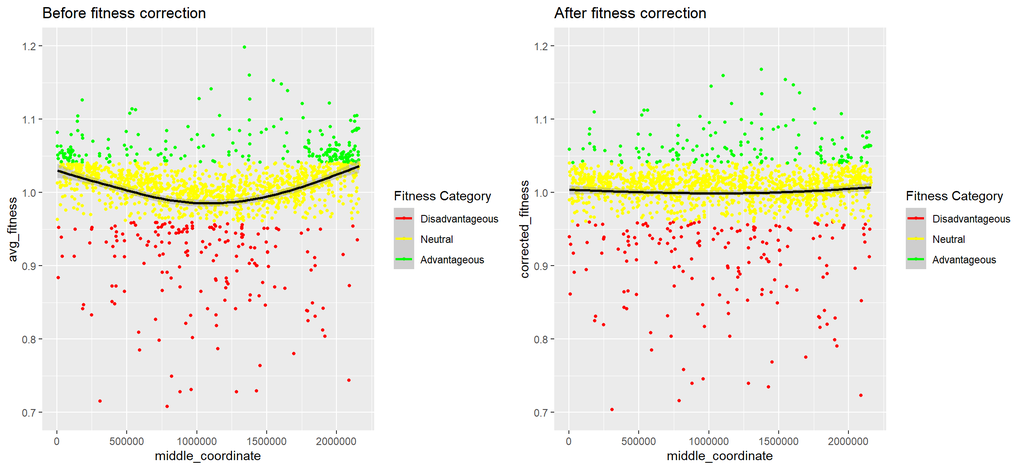

```r
color_categories_avg_fitness <- cut(fitness_df_all$avg_fitness, breaks = c(0, 0.96,
    1.04, Inf), labels = c("Disadvantageous", "Neutral", "Advantageous"))

color_categories_corrected_fitness <- cut(fitness_df_all$corrected_fitness, breaks = c(0,
    0.96, 1.04, Inf), labels = c("Disadvantageous", "Neutral", "Advantageous"))

# create the scatterplot for avg_fitness in the obj not divided in windows
plot_avg_fitness_df_all <- ggplot(fitness_df_all, aes(x = middle_coordinate, y = avg_fitness,
    color = color_categories_avg_fitness)) + geom_point(size = 1) + geom_smooth(method = "density") +
    geom_smooth(color = "black") + scale_color_manual(values = color_palette, labels = c("Disadvantageous",
    "Neutral", "Advantageous"), guide = guide_legend(title = "Fitness Category")) +
    ylim(0.7, 1.2) + labs(title = "Before fitness correction", x = "middle_coordinate",
    y = "avg_fitness")
# Create the scatterplot for corrected_fitness in the obj not divided in
# windows
plot_corrected_fitness_df_all <- ggplot(fitness_df_all, aes(x = middle_coordinate,
    y = corrected_fitness, color = color_categories_corrected_fitness)) + geom_point(size = 1) +
    geom_smooth(method = "density") + geom_smooth(color = "black") + scale_color_manual(values = color_palette,
    labels = c("Disadvantageous", "Neutral", "Advantageous"), guide = guide_legend(title = "Fitness Category")) +
    ylim(0.7, 1.2) + labs(title = "After fitness correction", x = "middle_coordinate",
    y = "corrected_fitness")

# Arrange the plots side by side
combined_plots <- grid.arrange(plot_avg_fitness_df_all, plot_corrected_fitness_df_all,
    ncol = 2)
```

The banana shape after fitness correction clearly disappears.

Let’s also plot a pie chart of the genes category before and after correction of fitness values.

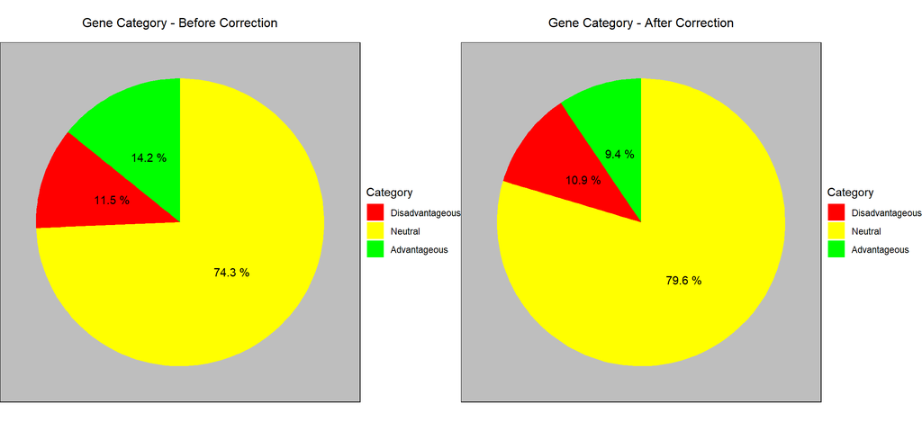

```r
# Create the category counts
gene_category_counts <- table(fitness_df_all$gene_category)
corrected_gene_category_counts <- table(fitness_df_all$corrected_gene_category)

# Combine the counts and categories into a data frame
category_counts <- data.frame(Category = names(gene_category_counts), Count = as.numeric(gene_category_counts),
    Corrected_Count = as.numeric(corrected_gene_category_counts))

# Calculate the percentages
category_counts <- category_counts %>%
    mutate(Percent = Count/sum(Count) * 100, Corrected_Percent = Corrected_Count/sum(Corrected_Count) *
        100)

# Plot the pie chart for gene_category
p_gene_category <- ggplot(category_counts, aes(x = "", y = Percent, fill = Category)) +
    geom_bar(width = 1, stat = "identity") + coord_polar("y", start = 0) + theme_void() +
    theme(legend.position = "right", panel.background = element_rect(fill = "gray"),
        plot.title = element_text(hjust = 0.5, vjust = 2, size = 12, margin = margin(0,
            0, 10, 0))) + labs(title = "Gene Category - Before Correction") + geom_text(aes(label = paste(round(Percent,
    1), "%")), position = position_stack(vjust = 0.5)) + scale_fill_manual(values = c("red",
    "yellow", "green"), breaks = c("Disadvantageous", "Neutral", "Advantageous"))


# Plot the pie chart for corrected_gene_category
p_corrected_gene_category <- ggplot(category_counts, aes(x = "", y = Corrected_Percent,
    fill = Category)) + geom_bar(width = 1, stat = "identity") + coord_polar("y",
    start = 0) + theme_void() + theme(legend.position = "right", panel.background = element_rect(fill = "gray"),
    plot.title = element_text(hjust = 0.5, vjust = 2, size = 12, margin = margin(0,
        0, 10, 0))) + labs(title = "Gene Category - After Correction") + geom_text(aes(label = paste(round(Corrected_Percent,
    1), "%")), position = position_stack(vjust = 0.5)) + scale_fill_manual(values = c("red",
    "yellow", "green"), breaks = c("Disadvantageous", "Neutral", "Advantageous"))


# Display the combined pie charts
grid.arrange(p_gene_category, p_corrected_gene_category, ncol = 2)
```

The number of Neutral locus after correction increases, instead the numbers of Disadvantageous and Advantageous decrease, especially the Advantageous once, proving again that before fitness correction many loci were misclassified.

## Radian coordinates

When working with radians in a linear regression model, it’s important to remember that radians represent angles in a circular or periodic context. To incorporate radians into the model, you can convert them to trigonometric functions such as sine and cosine. The `windows_properties` dataframe will be used.

```r
windows_properties_rad <- windows_properties

# Linear Regression model with sin and cos of radians as coefficients
lm_rad_coord <- lm(formula = avg_fitness ~ sin(radians) + cos(radians), data = windows_properties_rad)
summary(lm_rad_coord)
```

```
Call:
lm(formula = avg_fitness ~ sin(radians) + cos(radians), data = windows_properties_rad)

Residuals:
       Min         1Q     Median         3Q        Max
-0.0124321 -0.0069136  0.0007805  0.0066234  0.0103305

Coefficients:
              Estimate Std. Error t value Pr(>|t|)
(Intercept)   1.003120   0.001669 601.205  < 2e-16 ***
sin(radians) -0.001310   0.002380  -0.550    0.588
cos(radians)  0.021041   0.002339   8.996 2.81e-08 ***
---
Signif. codes:  0 '***' 0.001 '**' 0.01 '*' 0.05 '.' 0.1 ' ' 1

Residual standard error: 0.007824 on 19 degrees of freedom
Multiple R-squared:  0.8104,    Adjusted R-squared:  0.7905
F-statistic: 40.61 on 2 and 19 DF,  p-value: 1.378e-07
```

```r
# Linear Regression model with just cos of radians as coefficients
lm_rad_coord_cos <- lm(formula = avg_fitness ~ cos(radians), data = windows_properties_rad)
summary(lm_rad_coord_cos)
```

```
Call:
lm(formula = avg_fitness ~ cos(radians), data = windows_properties_rad)

Residuals:
       Min         1Q     Median         3Q        Max
-0.0135475 -0.0064098  0.0001044  0.0063671  0.0112596

Coefficients:
             Estimate Std. Error t value Pr(>|t|)
(Intercept)  1.003119   0.001639 611.963  < 2e-16 ***
cos(radians) 0.021038   0.002298   9.156 1.36e-08 ***
---
Signif. codes:  0 '***' 0.001 '**' 0.01 '*' 0.05 '.' 0.1 ' ' 1

Residual standard error: 0.007686 on 20 degrees of freedom
Multiple R-squared:  0.8074,    Adjusted R-squared:  0.7978
F-statistic: 83.84 on 1 and 20 DF,  p-value: 1.364e-08
```

`sin(radians)` is not a significant coefficient, since its p-value > 0.05. At the contrary `cos(radians)` is significant, so a linear model without sin has been fitted as well. R-squared is slightly higher in the model containing also `sin(radians)`, so `lm_rad_coord` will be used for further analysis. Anyway, in both case R-squared is quite high , indicating that approximately 81% of the variance in fitness can be explained by the linear model considering the coordinates as radians.

```r
# Predict window fitness with rad coordinates
predicted_fitness_rad <- predict(lm_rad_coord, windows_properties_rad)

# Correct window fitness with rad coordinates
windows_properties_rad$corrected_fitness <- windows_properties_rad$avg_fitness -
    predicted_fitness_rad + 1
```

Let’s plot the scatterplot before and after fitness correction.

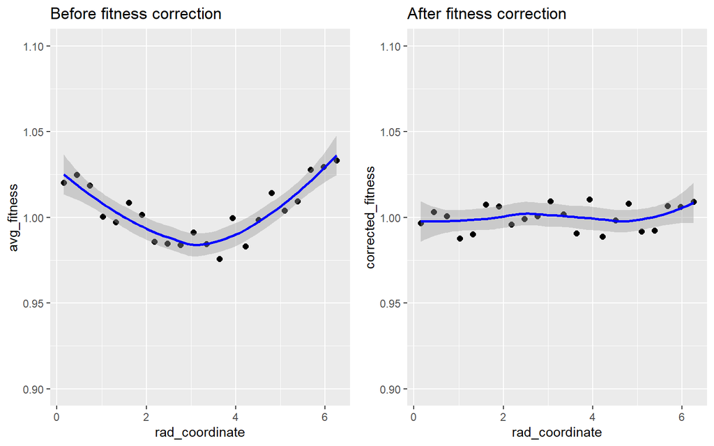

```r
# Create the scatterplot for avg_fitness
plot_avg_fitness_rad <- ggplot(windows_properties_rad, aes(x = radians, y = avg_fitness)) +
    geom_point(size = 2) + geom_smooth(method = "density") + geom_smooth(color = "blue") +
    ylim(0.9, 1.1) + labs(title = "Before fitness correction", x = "rad_coordinate",
    y = "avg_fitness")
# Create the scatterplot for corrected_fitness
plot_corrected_fitness_rad <- ggplot(windows_properties_rad, aes(x = radians, y = corrected_fitness)) +
    geom_point(size = 2) + geom_smooth(method = "density") + geom_smooth(color = "blue") +
    ylim(0.9, 1.1) + labs(title = "After fitness correction", x = "rad_coordinate",
    y = "corrected_fitness")

# Arrange the plots side by side
combined_plots <- grid.arrange(plot_avg_fitness_rad, plot_corrected_fitness_rad,
    ncol = 2)
```

The linear model with radian coordinates on the object divided in windows performs well, correcting the banana shape belonging to the plot without fitness correction.

It can now be used to correct the fitness values in the original Grange object.

```r
fitness_df_all_rad <- data.frame(radians = fitness$radianCoord, avg_fitness = fitness$avg_fitness,
    gene_category = fitness$geneCategory, locus = names(fitness))
# Correcting fitness values
fitness_df_all_rad$corrected_fitness <- fitness_df_all_rad$avg_fitness - predict(lm_rad_coord,
    fitness_df_all_rad) + 1

# create another column with the corrected gene category
fitness_df_all_rad$corrected_gene_category <- cut(fitness_df_all_rad$corrected_fitness,
    breaks = c(0, 0.96, 1.04, Inf), labels = c("Disadvantageous", "Neutral", "Advantageous"))
```

Let’s visualize 2 scatter plots of fitness values before and after correction against the `radians` coordinates.

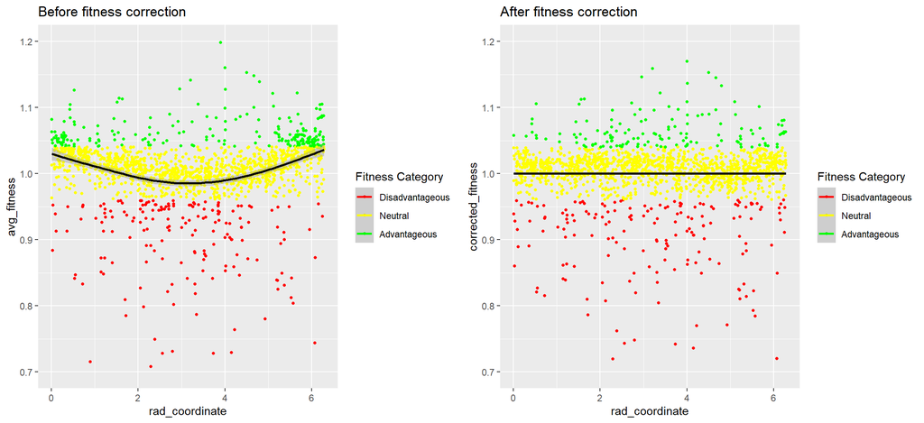

```r
color_categories_avg_fitness_rad <- cut(fitness_df_all_rad$avg_fitness, breaks = c(0,
    0.96, 1.04, Inf), labels = c("Disadvantageous", "Neutral", "Advantageous"))

color_categories_corrected_fitness_rad <- cut(fitness_df_all_rad$corrected_fitness,
    breaks = c(0, 0.96, 1.04, Inf), labels = c("Disadvantageous", "Neutral", "Advantageous"))

# create the scatterplot for avg_fitness in the obj not divided in windows
plot_avg_fitness_df_all_rad <- ggplot(fitness_df_all_rad, aes(x = radians, y = avg_fitness,
    color = color_categories_avg_fitness_rad)) + geom_point(size = 1) + geom_smooth(method = "density") +
    geom_smooth(color = "black") + scale_color_manual(values = color_palette, labels = c("Disadvantageous",
    "Neutral", "Advantageous"), guide = guide_legend(title = "Fitness Category")) +
    ylim(0.7, 1.2) + labs(title = "Before fitness correction", x = "rad_coordinate",
    y = "avg_fitness")
# Create the scatterplot for corrected_fitness in the obj not divided in
# windows
plot_corrected_fitness_df_all_rad <- ggplot(fitness_df_all_rad, aes(x = radians,
    y = corrected_fitness, color = color_categories_corrected_fitness_rad)) + geom_point(size = 1) +
    geom_smooth(method = "density") + geom_smooth(color = "black") + scale_color_manual(values = color_palette,
    labels = c("Disadvantageous", "Neutral", "Advantageous"), guide = guide_legend(title = "Fitness Category")) +
    ylim(0.7, 1.2) + labs(title = "After fitness correction", x = "rad_coordinate",
    y = "corrected_fitness")

# Arrange the plots side by side
combined_plots_rad <- grid.arrange(plot_avg_fitness_df_all_rad, plot_corrected_fitness_df_all_rad,
    ncol = 2)
```

Let’s also visualize the Gene category change before and after fitness values correction.

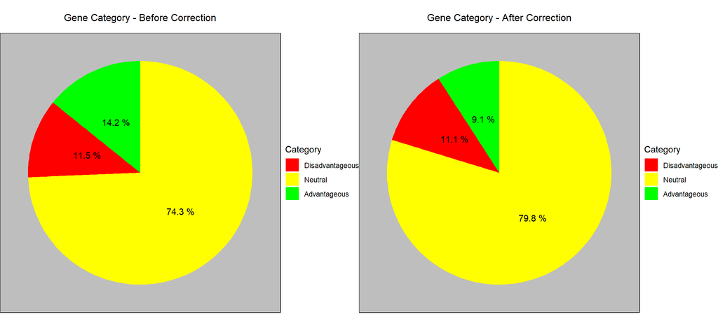

```r
# Create the category counts
gene_category_counts_rad <- table(fitness_df_all_rad$gene_category)
corrected_gene_category_counts_rad <- table(fitness_df_all_rad$corrected_gene_category)

# Combine the counts and categories into a data frame
category_counts_rad <- data.frame(Category = names(gene_category_counts_rad), Count = as.numeric(gene_category_counts_rad),
    Corrected_Count = as.numeric(corrected_gene_category_counts_rad))

# Calculate the percentages
category_counts_rad <- category_counts_rad %>%
    mutate(Percent = Count/sum(Count) * 100, Corrected_Percent = Corrected_Count/sum(Corrected_Count) *
        100)

# Plot the pie chart for gene_category
p_gene_category_rad <- ggplot(category_counts_rad, aes(x = "", y = Percent, fill = Category)) +
    geom_bar(width = 1, stat = "identity") + coord_polar("y", start = 0) + theme_void() +
    theme(legend.position = "right", panel.background = element_rect(fill = "gray"),
        plot.title = element_text(hjust = 0.5, vjust = 2, size = 12, margin = margin(0,
            0, 10, 0))) + labs(title = "Gene Category - Before Correction") + geom_text(aes(label = paste(round(Percent,
    1), "%")), position = position_stack(vjust = 0.5)) + scale_fill_manual(values = c("red",
    "yellow", "green"), breaks = c("Disadvantageous", "Neutral", "Advantageous"))


# Plot the pie chart for corrected_gene_category
p_corrected_gene_category_rad <- ggplot(category_counts_rad, aes(x = "", y = Corrected_Percent,
    fill = Category)) + geom_bar(width = 1, stat = "identity") + coord_polar("y",
    start = 0) + theme_void() + theme(legend.position = "right", panel.background = element_rect(fill = "gray"),
    plot.title = element_text(hjust = 0.5, vjust = 2, size = 12, margin = margin(0,
        0, 10, 0))) + labs(title = "Gene Category - After Correction") + geom_text(aes(label = paste(round(Corrected_Percent,
    1), "%")), position = position_stack(vjust = 0.5)) + scale_fill_manual(values = c("red",
    "yellow", "green"), breaks = c("Disadvantageous", "Neutral", "Advantageous"))


# Display the combined pie charts
grid.arrange(p_gene_category_rad, p_corrected_gene_category_rad, ncol = 2)
```

The banana shape is corrected totally. Compared to the linear model with linear coordinates, the model with radian coordinates classifies as “Neutral” and “Disadvantageous” 0.2% more loci. At the same time “Advantageous” loci after correction have decreased even more by 0.3%.

### Gene category transition

In order to visualize the gene category transition before and after fitness correction a stacked barplot has been used.

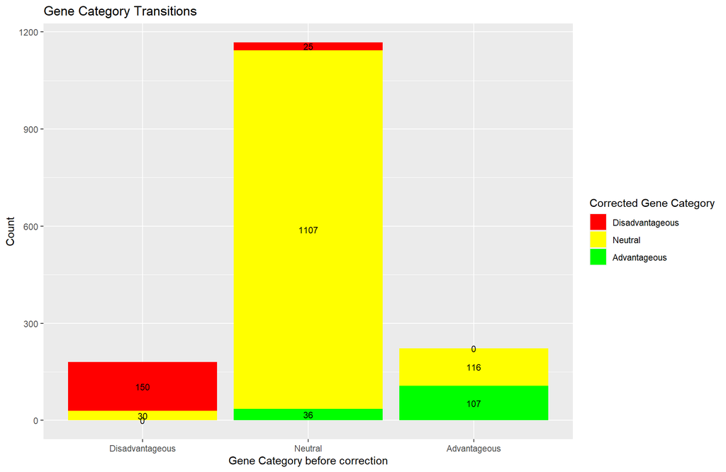

```r
# Calculate the transition counts
transition_counts <- table(fitness_df_all_rad$gene_category, fitness_df_all_rad$corrected_gene_category)

# Reshape the data for plotting
transition_df <- as.data.frame.table(transition_counts)

# Plot the transitions
ggplot(transition_df, aes(x = Var1, y = Freq, fill = Var2)) + geom_bar(stat = "identity",
    position = "stack") + geom_text(aes(label = Freq), position = position_stack(vjust = 0.5),
    color = "black", size = 3) + xlab("Gene Category before correction") + ylab("Count") +
    labs(fill = "Corrected Gene Category") + scale_fill_manual(values = c(Advantageous = "green",
    Neutral = "yellow", Disadvantageous = "red")) + ggtitle("Gene Category Transitions")
```

After fitness correction, 30 loci have changed from Disadvantageous to Neutral, 36 loci have changed from Neutral to Advantageous and 25 to Disadvantageous, and 116 loci have changed from Advantageous to Neutral.

# Gene ontology annotation

It’s interesting to check the GO biological process of the loci that where categorized as “Neutral” before the correction, and were categorized as either “Advantageous” or “Disadvantageous” after fitness correction, because they might have a critical role in cell survival.

The loci names have been saved to two different txt file based on if they were categorized as “Advantageous” or “Disadvantageous” after correction. The txts were given as input to [UniProt](https://www.uniprot.org/) online tool. The results (loci names + biological process ) were then saved into two excel files and loaded back in the vignette as dataframes.

```r
# Filter the dataframe based on the conditions
filtered_df_adv <- fitness_df_all_rad[fitness_df_all_rad$gene_category == "Neutral" &
    (fitness_df_all_rad$corrected_gene_category == "Advantageous"), ]
filtered_df_dis <- fitness_df_all_rad[fitness_df_all_rad$gene_category == "Neutral" &
    (fitness_df_all_rad$corrected_gene_category == "Disadvantageous"), ]
# Get the locus column names from the filtered dataframes
locus_names_adv <- filtered_df_adv$locus
locus_names_dis <- filtered_df_dis$locus

# Create two character vectors with whitespace-separated names
locus_names_string_adv <- paste(locus_names_adv, collapse = " ")
locus_names_string_dis <- paste(locus_names_dis, collapse = " ")

# Save the locus names to a text file

writeLines(locus_names_string_adv, "locus_names_adv.txt")
writeLines(locus_names_string_dis, "locus_names_dis.txt")

library(readxl)

df_adv <- read_excel("uniprot-download_adv.xlsx", col_names = TRUE)
df_adv <- df_adv[, c(1, 3)]

df_dis <- read_excel("uniprot-download_dis.xlsx", col_names = TRUE)
df_dis <- df_dis[, c(1, 3)]
```

The biological processes among genes that were categorized as “Neutral”, and that after fitness connection were categorized as “Advantageous”, are listed below:

```r
# Split the strings by semicolon and create a list of all the strings
all_strings_adv <- strsplit(df_adv$`Gene Ontology (biological process)`, ";")

# Flatten the list into a single vector
all_strings_adv <- unlist(all_strings_adv)

# Remove leading and trailing white spaces from the strings
all_strings_adv <- trimws(all_strings_adv)

# Count the frequency of each string
string_counts_adv <- table(all_strings_adv)

string_counts_adv
```

```
all_strings_adv
      'de novo' pyrimidine nucleobase biosynthetic process [GO:0006207]
                                                                      1
                        'de novo' UMP biosynthetic process [GO:0044205]
                                                                      1
        5-phosphoribose 1-diphosphate biosynthetic process [GO:0006015]
                                                                      1
                             arginine biosynthetic process [GO:0006526]
                                                                      1
                          bacteriocin biosynthetic process [GO:0030152]
                                                                      1
                                    cell wall organization [GO:0071555]
                                                                      1
                       cellular metabolic compound salvage [GO:0043094]
                                                                      1
                             cellular response to stimulus [GO:0051716]
                                                                      1
                     deoxyribonucleotide catabolic process [GO:0009264]
                                                                      1
                      killing of cells of another organism [GO:0031640]
                                                                      1
        negative regulation of DNA-templated transcription [GO:0045892]
                                                                      1
                               nitrogen compound transport [GO:0071705]
                                                                      1
                                nucleotide-excision repair [GO:0006289]
                                                                      1
                       organic substance metabolic process [GO:0071704]
                                                                      1
poly(ribitol phosphate) teichoic acid biosynthetic process [GO:1902012]
                                                                      1
                           protein complex oligomerization [GO:0051259]
                                                                      1
                              protein modification process [GO:0036211]
                                                                      1
                                            protein repair [GO:0030091]
                                                                      1
                                               proteolysis [GO:0006508]
                                                                      1
                  pyridoxal phosphate biosynthetic process [GO:0042823]
                                                                      1
                 regulation of DNA-templated transcription [GO:0006355]
                                                                      1
                            removal of superoxide radicals [GO:0019430]
                                                                      1
                              response to oxidative stress [GO:0006979]
                                                                      1
                                              SOS response [GO:0009432]
                                                                      1
```

Some of the biological processes listed above relate to cellular response against stress, such as protein repair, responsiveness towards oxidative stress, nucleotide-excision repair, removal of superoxide radicals and SOS response. It can be guessed that removal of genes with these particular biological processes could result in bacterium’s inability to trigger a reaction for avoiding the impact of stressful circumstances on cell survival; or the apoptosis resulting from stress situations might not occur leading to enhanced fitness.

The biological processes among genes that were categorized as “Neutral”, and that after fitness connection were categorized as “Disadvantageous”, are listed below:

```r
# Split the strings by semicolon and create a list of all the strings
all_strings_dis <- strsplit(df_dis$`Gene Ontology (biological process)`, ";")

# Flatten the list into a single vector
all_strings_dis <- unlist(all_strings_dis)

# Remove leading and trailing white spaces from the strings
all_strings_dis <- trimws(all_strings_dis)

# Count the frequency of each string
string_counts_dis <- table(all_strings_dis)

string_counts_dis
```

```
all_strings_dis
              carbohydrate derivative biosynthetic process [GO:1901137]
                                                                      1
                            carbohydrate metabolic process [GO:0005975]
                                                                      1
                                             cell division [GO:0051301]
                                                                      1
                                     chromosome separation [GO:0051304]
                                                                      1
                                           DNA replication [GO:0006260]
                                                                      2
                       DNA restriction-modification system [GO:0009307]
                                                                      1
              enzyme-directed rRNA pseudouridine synthesis [GO:0000455]
                                                                      1
                               galactose metabolic process [GO:0006012]
                                                                      1
                               glutamine metabolic process [GO:0006541]
                                                                      1
        negative regulation of DNA-templated transcription [GO:0045892]
                                                                      1
negative regulation of purine nucleobase metabolic process [GO:0045982]
                                                                      1
                                         peptide transport [GO:0015833]
                                                                      1
                                           phosphorylation [GO:0016310]
                                                                      1
                                           protein folding [GO:0006457]
                                                                      1
                                         protein transport [GO:0015031]
                                                                      1
                 thiamine diphosphate biosynthetic process [GO:0009229]
                                                                      1
                                thiamine metabolic process [GO:0006772]
                                                                      1
                                   transmembrane transport [GO:0055085]
                                                                      1
                  tRNA wobble adenosine to inosine editing [GO:0002100]
                                                                      1
```

Many biological processes listed above refer to metabolic processes and processes essential for cell life, such as DNA replication, cell division and protein folding. So a mutation in genes with these biological processes might be crucial for cell survival.

# Conclusion

Using both linear and radian coordinates as coefficients in order to correct fitness values in a linear regression model was successful.

The model with radian coordinates performed slightly better, correcting the banana shape totally. This allowed to correct fitness of genes that were misclassified as ‘Advantageous’, ‘Disadvantageous’ or ‘Neutral’.

By annotating the loci that were wrongly classified as ‘Neutral’ it was possible to retrieve the biological processes of genes that might have a critical role in cell survival.